# CSGO K-means

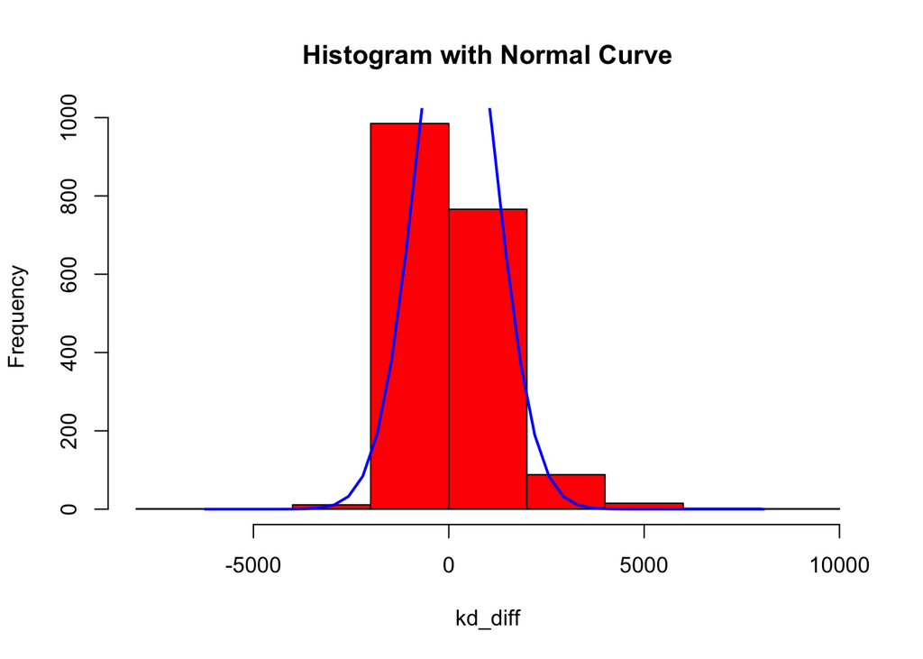

```r
x <- cs_df1$kd_diff
h <- hist(x, breaks=10, col="red", xlab="kd_diff",main="Histogram with Normal Curve")
xfit<-seq(min(x),max(x),length=40)
yfit<-dnorm(xfit,mean=mean(x),sd=sd(x))
yfit <- yfit*diff(h$mids[1:2])*length(x)
lines(xfit, yfit, col="blue", lwd=2)
```

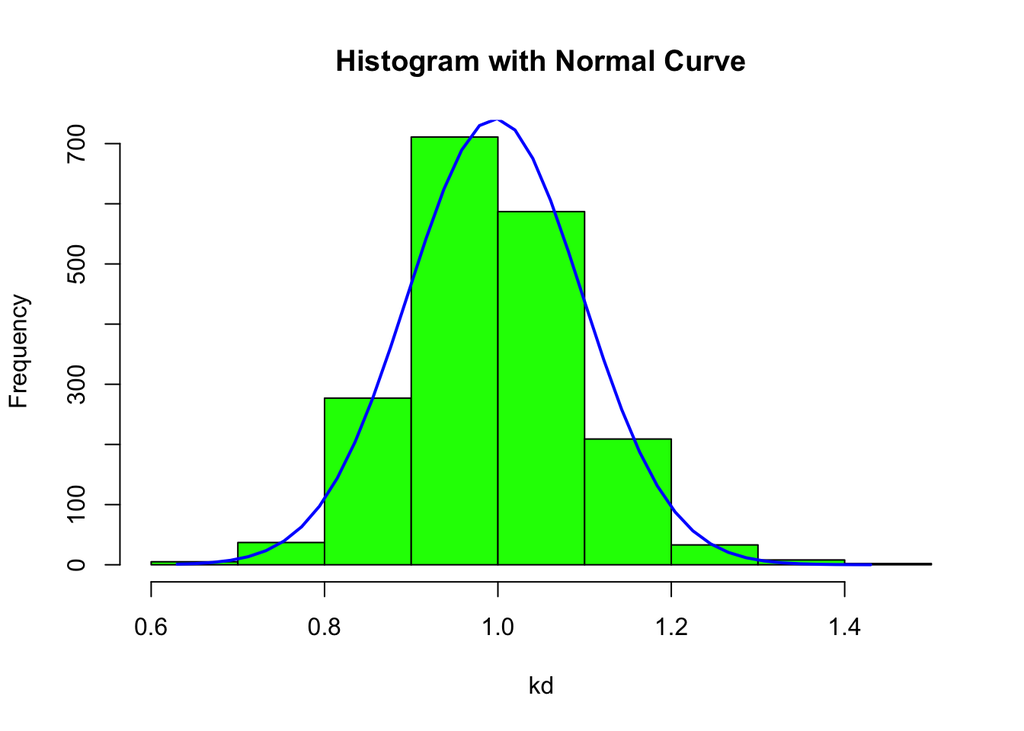

```r
x <- cs_df1$kd
h <- hist(x, breaks=10, col="green", xlab="kd",main="Histogram with Normal Curve")
xfit<-seq(min(x),max(x),length=40)
yfit<-dnorm(xfit,mean=mean(x),sd=sd(x))
yfit <- yfit*diff(h$mids[1:2])*length(x)
lines(xfit, yfit, col="blue", lwd=2)
```

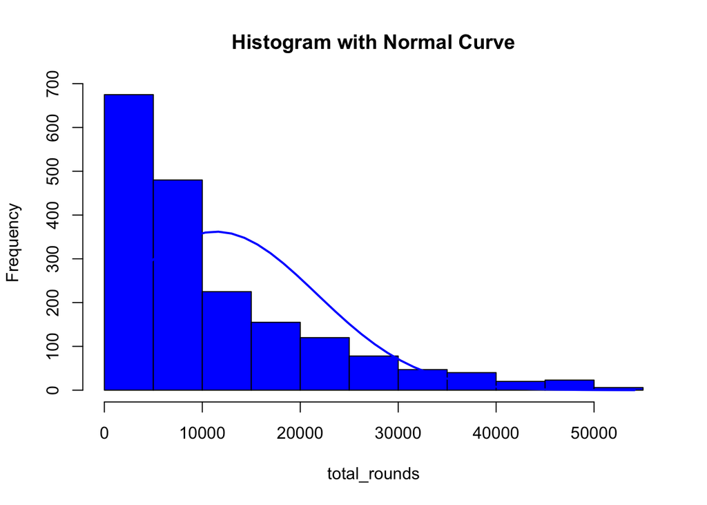

```r
x <- cs_df1$total_rounds
h <- hist(x, breaks=10, col="blue", xlab="total_rounds",main="Histogram with Normal Curve")
xfit<-seq(min(x),max(x),length=40)
yfit<-dnorm(xfit,mean=mean(x),sd=sd(x))
yfit <- yfit*diff(h$mids[1:2])*length(x)
lines(xfit, yfit, col="blue", lwd=2)
```

As we can see from the plot below, relationship between kd raiton and rating seems to be linear

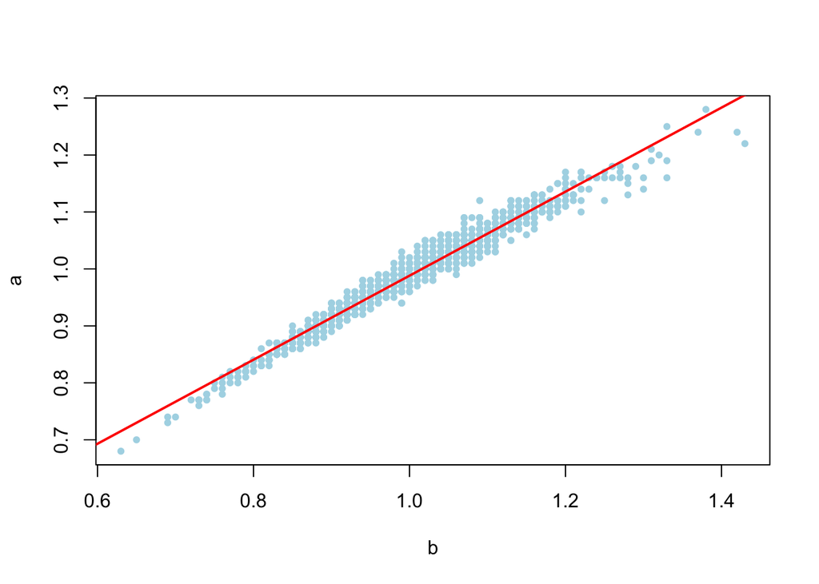

```r
a <- cs_df1$rating
b <- cs_df1$kd

plot(b, a, pch = 20, col = "lightblue")
abline(lm(a ~ b), col = "red", lwd = 2)
```

There is some correlation between rating and kd_diff. Normally, the better your kd_diff is the higher rating you have.

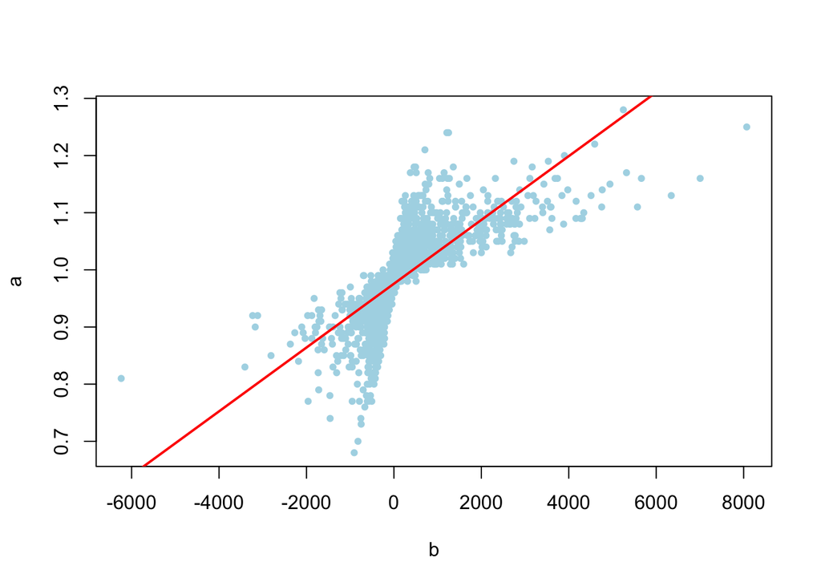

```r
a <- cs_df1$rating
b <- cs_df1$kd_diff

plot(b, a, pch = 20, col = "lightblue")
abline(lm(a ~ b), col = "red", lwd = 2)
```

Not much correlation between rating and total_maps, but in general, the more maps you play, more chance you have to have a good rating.

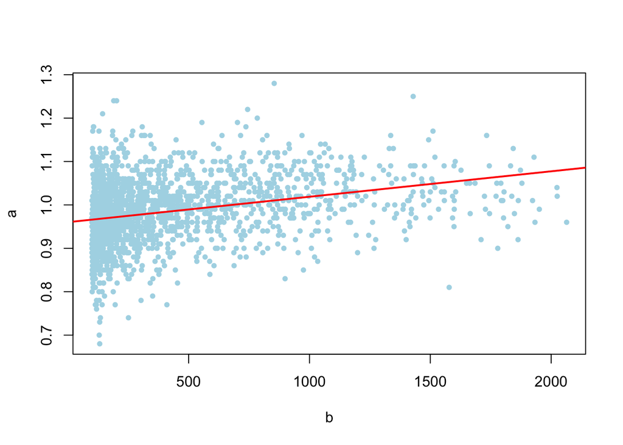

```r
a <- cs_df1$rating
b <- cs_df1$total_maps

plot(b, a, pch = 20, col = "lightblue")
abline(lm(a ~ b), col = "red", lwd = 2)
```

This plot is pretty similar to the previous one.

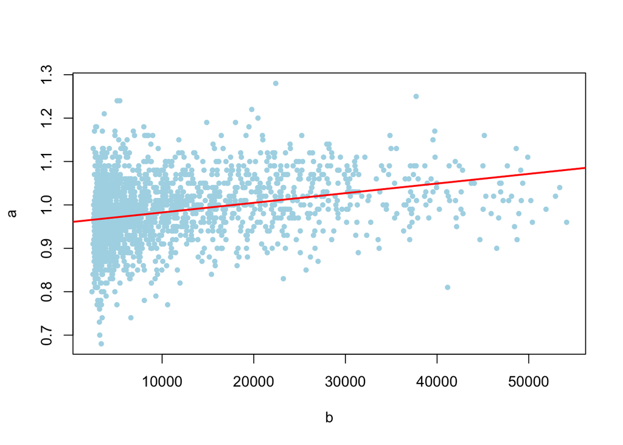

```r
a <- cs_df1$rating
b <- cs_df1$total_rounds

plot(b, a, pch = 20, col = "lightblue")
abline(lm(a ~ b), col = "red", lwd = 2)
```

Total_rounds and total_maps are basically interchangable.

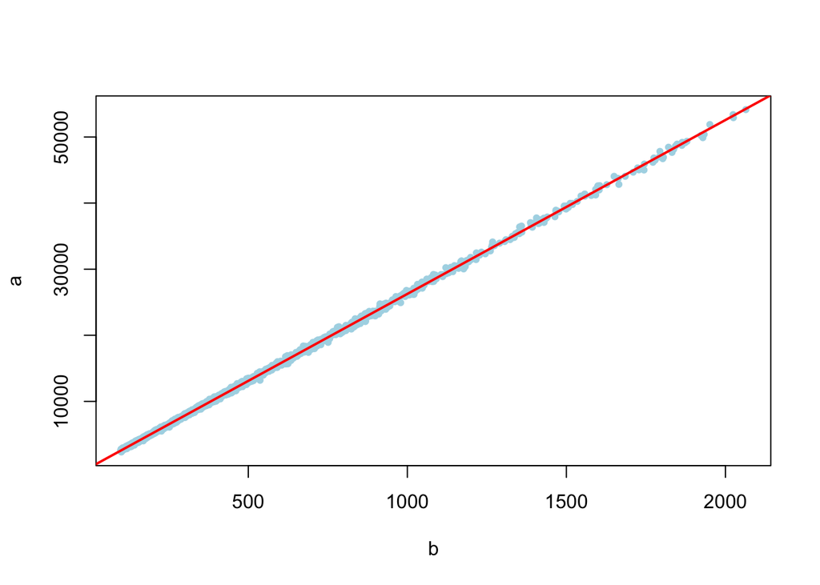

```r
a <- cs_df1$total_rounds
b <- cs_df1$total_maps

plot(b, a, pch = 20, col = "lightblue")
abline(lm(a ~ b), col = "red", lwd = 2)
```

Not much correlation between number of maps a player plays and his kd ratio.

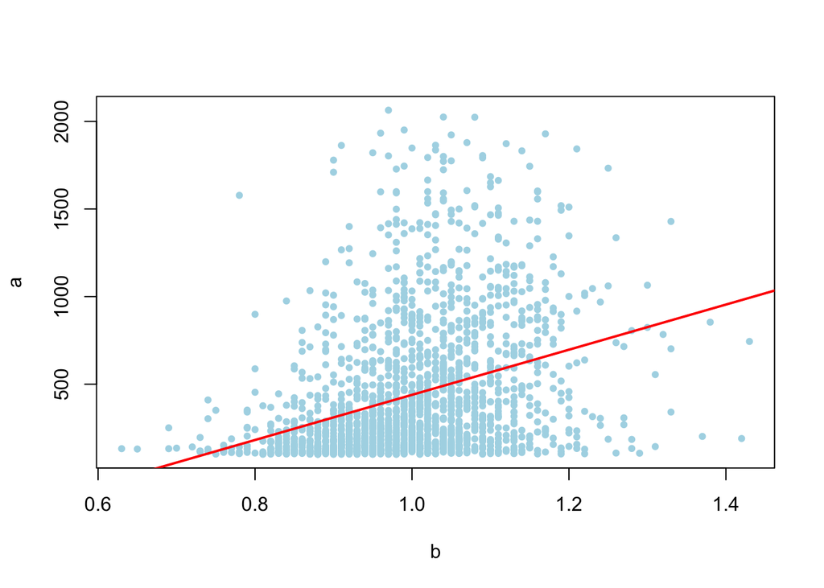

```r
a <- cs_df1$total_maps
b <- cs_df1$kd

plot(b, a, pch = 20, col = "lightblue")
abline(lm(a ~ b), col = "red", lwd = 2)
```

##In CSGO, rating of 1.2 and more is considered to be very high. Lets look at the players with the highest ratings.But it needs to be said that rating only does not say much about the player, yes it is good to have a higher rating but, more important factor is who you have that high rating against.

```r
avg_rating_all <- aggregate(rating ~ name, cs_df1, mean)
top_rated <- avg_rating_all %>% filter(rating > 1.2)
num_top_rated <- count(top_rated)
flextable(num_top_rated)
```

| n |
| --- |
| 6 |

Lets look at rating by countries and see wich country has rating greater than 1.

```r
library(kableExtra)
library(gt)
teams_nat <- aggregate(rating ~ country , cs_df1,mean)
flextable(teams_nat %>% filter(rating>1))
```

| country | rating |
| --- | --- |
| Bosnia and Herzegovina | 1.015000 |
| Chile | 1.020909 |
| Colombia | 1.010000 |
| Czech Republic | 1.009412 |
| Hong Kong | 1.120000 |
| India | 1.036667 |
| Israel | 1.058000 |
| Jordan | 1.006667 |
| Korea | 1.020714 |
| Kyrgyzstan | 1.005000 |
| Latvia | 1.032000 |
| Lithuania | 1.004615 |
| Malaysia | 1.005000 |
| Mongolia | 1.003158 |
| Montenegro | 1.050000 |
| Netherlands | 1.011000 |
| New Zealand | 1.043846 |
| Peru | 1.030000 |
| Philippines | 1.017273 |
| South Africa | 1.021667 |
| Thailand | 1.002308 |
| Tunisia | 1.090000 |
| Turkey | 1.011000 |
| Uruguay | 1.005000 |

See which country have kd ratio greater than 1

```r
teams_kd <- aggregate(kd~country  , cs_df1,mean)
flextable(teams_kd %>% filter(kd>1))
```

| country | kd |
| --- | --- |
| Argentina | 1.001000 |
| Bosnia and Herzegovina | 1.022500 |
| Brazil | 1.010507 |
| Chile | 1.034545 |
| Colombia | 1.024000 |
| Czech Republic | 1.024706 |
| Denmark | 1.000417 |
| Estonia | 1.008462 |
| Hong Kong | 1.180000 |
| India | 1.058333 |
| Israel | 1.090000 |
| Jordan | 1.013333 |
| Korea | 1.050000 |
| Kyrgyzstan | 1.020000 |
| Latvia | 1.052000 |
| Lithuania | 1.016923 |
| Malaysia | 1.026250 |
| Mongolia | 1.010526 |
| Montenegro | 1.050000 |
| Netherlands | 1.025000 |
| New Zealand | 1.079231 |
| Peru | 1.032000 |
| Philippines | 1.032727 |
| Russia | 1.001695 |
| South Africa | 1.047222 |
| Sweden | 1.001043 |
| Thailand | 1.016538 |
| Tunisia | 1.090000 |
| Turkey | 1.029500 |
| United Arab Emirates | 1.010000 |
| Uruguay | 1.027500 |

From correlation matrix below, we can observe that there is a linear orrelation between total_rounds and totla_maps as we already said that before,kd ratio and kd_diff,rating and kd_diff, rating and kd ratio.

```r
cs_df4 = cs_df1[,-1]
cs_df4 = cs_df4[,-1]
cs_df4 = cs_df4[,-1]
flextable(as.data.frame(as.table(cor(cs_df4, method = "pearson", use = "complete.obs"))))
```

| Var1 | Var2 | Freq |
| --- | --- | --- |
| total_maps | total_maps | 1.0000000 |
| total_rounds | total_maps | 0.9998003 |
| kd_diff | total_maps | 0.4438144 |
| kd | total_maps | 0.3310591 |
| rating | total_maps | 0.3038863 |
| total_maps | total_rounds | 0.9998003 |
| total_rounds | total_rounds | 1.0000000 |
| kd_diff | total_rounds | 0.4428830 |
| kd | total_rounds | 0.3305614 |
| rating | total_rounds | 0.3034428 |
| total_maps | kd_diff | 0.4438144 |
| total_rounds | kd_diff | 0.4428830 |
| kd_diff | kd_diff | 1.0000000 |
| kd | kd_diff | 0.7603976 |
| rating | kd_diff | 0.7329668 |
| total_maps | kd | 0.3310591 |
| total_rounds | kd | 0.3305614 |
| kd_diff | kd | 0.7603976 |
| kd | kd | 1.0000000 |
| rating | kd | 0.9816469 |
| total_maps | rating | 0.3038863 |
| total_rounds | rating | 0.3034428 |
| kd_diff | rating | 0.7329668 |
| kd | rating | 0.9816469 |
| rating | rating | 1.0000000 |

Heatmap of the dataset

```r
library("reshape")                                                # Load reshape package
```

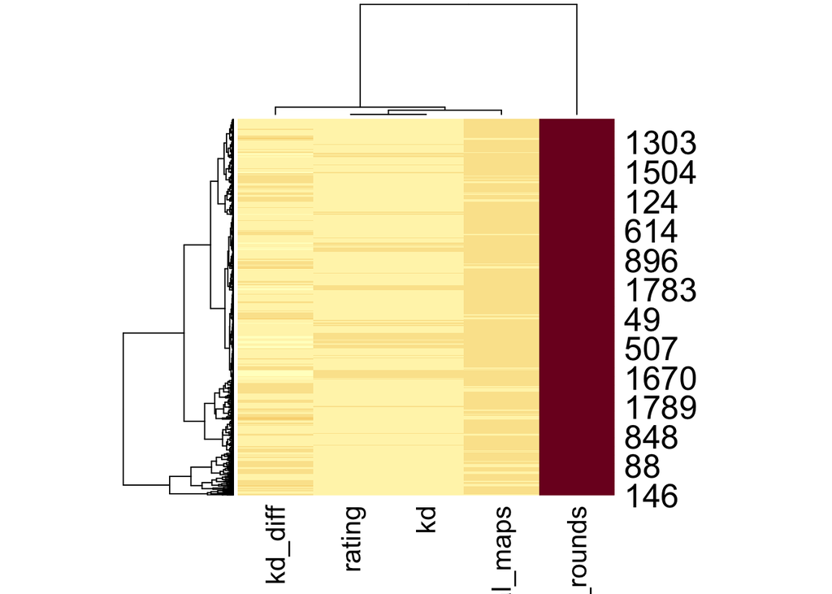

```r
heatmap(as.matrix(cs_df4), cexRow =2, margins = c(5,5))
```

# Now lets try Linear Regression plots

```r
library(ggplot2)
library(dplyr)
library(broom)
library(ggpubr)

m <- lm(rating ~ kd, data = cs_df4)

summary(m)
```

```
##
## Call:
## lm(formula = rating ~ kd, data = cs_df4)
##
## Residuals:
##       Min        1Q    Median        3Q       Max
## -0.085422 -0.009150 -0.000307  0.008716  0.065426
##
## Coefficients:
##             Estimate Std. Error t value Pr(>|t|)
## (Intercept) 0.250385   0.003323   75.35   <2e-16 ***
## kd          0.737787   0.003317  222.41   <2e-16 ***
## ---
## Signif. codes:  0 '***' 0.001 '**' 0.01 '*' 0.05 '.' 0.1 ' ' 1
##
## Residual standard error: 0.01441 on 1867 degrees of freedom
## Multiple R-squared:  0.9636, Adjusted R-squared:  0.9636
## F-statistic: 4.947e+04 on 1 and 1867 DF,  p-value: < 2.2e-16
```

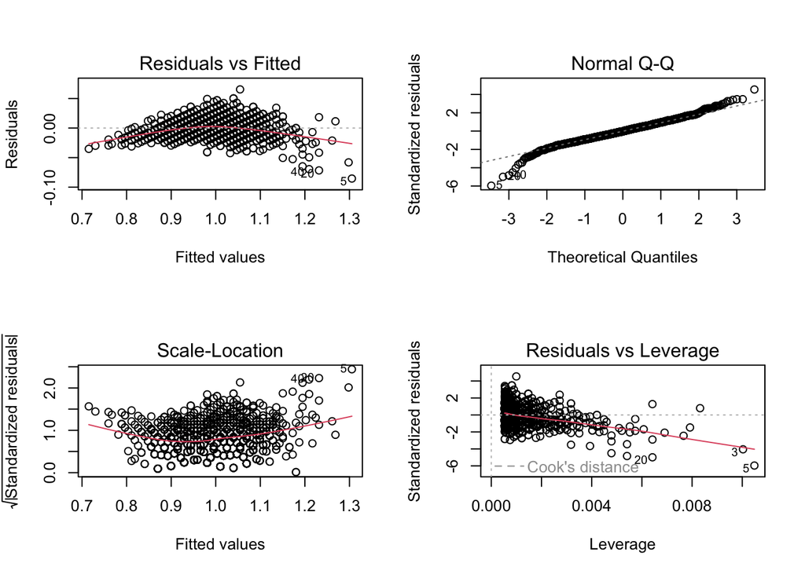

```r
par(mfrow=c(2,2))
plot(m)
```

```r
par(mfrow=c(1,1))
```

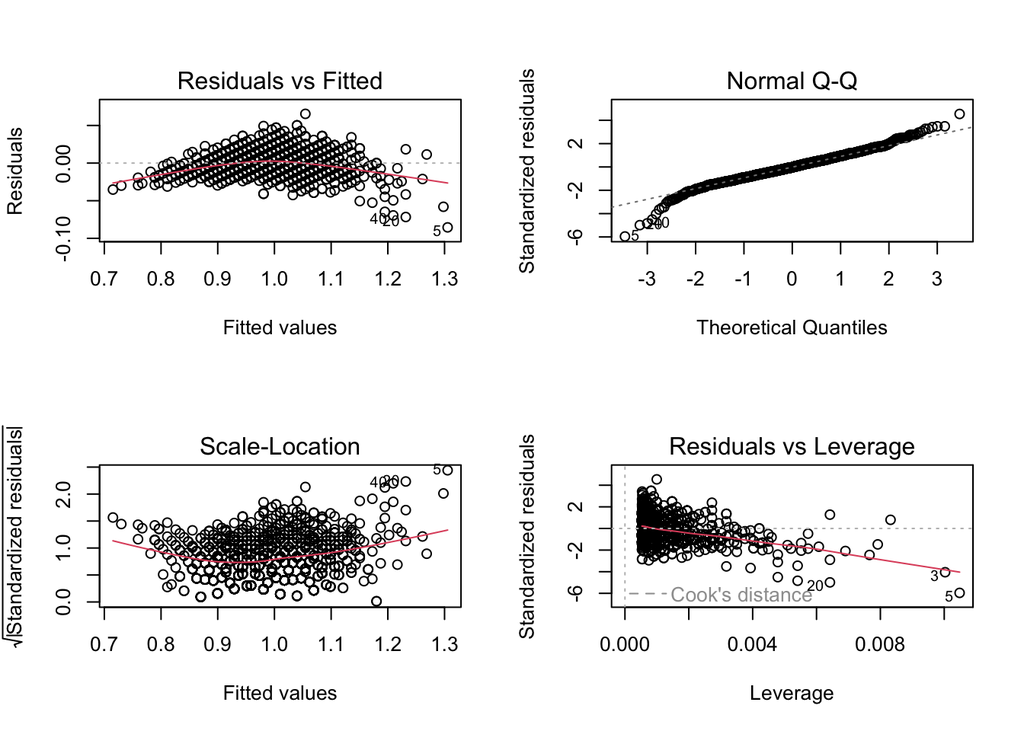

```r
par(mfrow=c(2,2))
plot(m)
```

```r
par(mfrow=c(1,1))
```

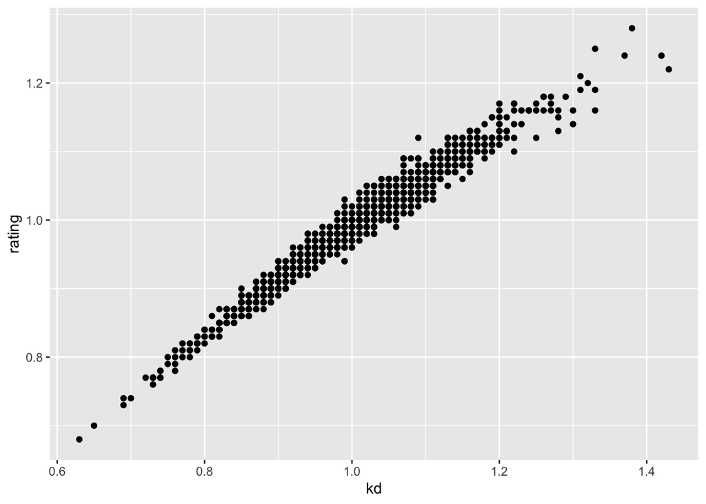

```r
p<-ggplot(cs_df4, aes(x=kd, y=rating))+
                     geom_point()
p
```

As we can see the kd ratio is the best predicting feature of out all the features.

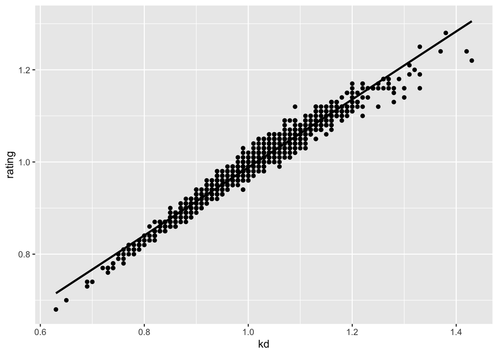

```r
p <- p+ geom_smooth(method="lm", col="black")
p
```

# Conclusions

After exploring the dataset, we can confidently say that the rating is mostly dependent on the kd ratio of the players which is in linear relationship with kd_diff. Playing more maps means playing more rounds and that means that a player has higher chance of having better kd ratio or kd_diff that means that he/she has a higher chance to have a higher rating.